# document

## About the Author

This report was authored by Ayoub Majjid, a fifth-year computer engineering student at EMSI with a background in Experimental Sciences. His academic journey has provided a strong foundation in mathematics, physics, and chemistry, and has shaped a growing expertise in technology, system design, and data engineering.

Ayoub currently serves as Tech Lead and Entrepreneur at Intellcap, where he leads three innovation projects focused on building impactful and scalable startup solutions. His work emphasizes transforming ideas into robust technical systems, with a particular interest in data platforms, system architecture, and end-to-end engineering workflows.

Email: ayoub@majjid.com  
Website: https://majjid.com

## Copyright & Disclaimer

© 2026 **Ayoub Majjid**. All rights reserved.

This report is provided for **educational and professional demonstration purposes**.  
The MIMIC-III dataset remains the property of its respective owners and is used in accordance with applicable data usage agreements.

No patient-identifiable information is disclosed or altered in this document.

# Bronze Layer Analysis

This notebook analyzes the **Bronze Layer** of the MIMIC-III Data Warehouse.

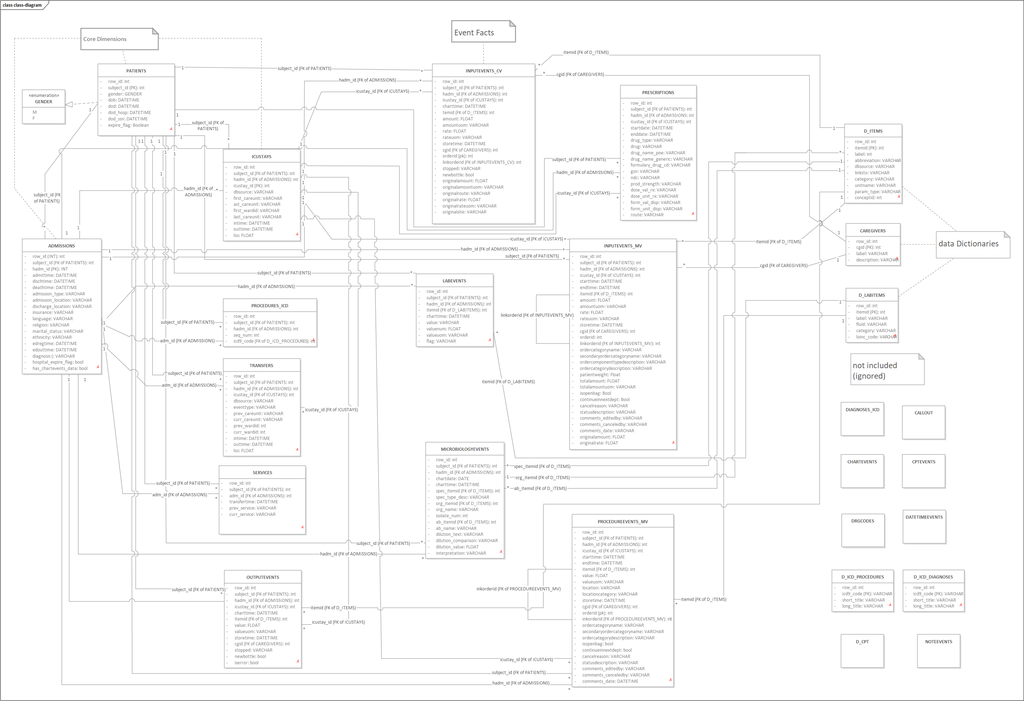

## What is the Bronze Layer?

The Bronze layer contains **raw data** loaded directly from CSV files with minimal transformation.

- Data is preserved in its original format
- No data cleaning or validation
- Source of truth for raw data

```python
# Setup
import sys
sys.path.insert(0, '../../..')

import pandas as pd
from sqlalchemy import text
from app.shared import get_db

pd.set_option('display.max_columns', None)
pd.set_option('display.width', None)
```

```python
# Helper function to query and display data
def query_df(sql, limit=10):
    with get_db() as session:
        result = session.execute(text(sql))
        df = pd.DataFrame(result.fetchall(), columns=result.keys())
    return df.head(limit) if limit else df

def table_count(schema, table):
    with get_db() as session:
        return session.execute(text(f"SELECT COUNT(*) FROM {schema}.{table}")).scalar()
```

## PATIENTS Table

**Description**: Core patient demographics table containing one row per patient.

[output not shown]

```python
print(f"Total Patients: {table_count('bronze', 'patients'):,}")
query_df("SELECT * FROM bronze.patients ORDER BY subject_id LIMIT 5")
```

[output not shown]

```
2026-01-01 14:33:03,272 INFO sqlalchemy.engine.Engine show standard_conforming_strings
2026-01-01 14:33:03,276 INFO sqlalchemy.engine.Engine [raw sql] {}
2026-01-01 14:33:03,281 INFO sqlalchemy.engine.Engine BEGIN (implicit)
2026-01-01 14:33:03,285 INFO sqlalchemy.engine.Engine SELECT COUNT(*) FROM bronze.patients
2026-01-01 14:33:03,290 INFO sqlalchemy.engine.Engine [generated in 0.00604s] {}
2026-01-01 14:33:03,304 INFO sqlalchemy.engine.Engine COMMIT
Total Patients: 100
2026-01-01 14:33:03,312 INFO sqlalchemy.engine.Engine BEGIN (implicit)
2026-01-01 14:33:03,314 INFO sqlalchemy.engine.Engine SELECT * FROM bronze.patients ORDER BY subject_id LIMIT 5
2026-01-01 14:33:03,316 INFO sqlalchemy.engine.Engine [generated in 0.00171s] {}
2026-01-01 14:33:03,339 INFO sqlalchemy.engine.Engine COMMIT
```

|  | row_id | subject_id | gender | dob | dod | dod_hosp | dod_ssn | expire_flag | created_at | updated_at |
| --- | --- | --- | --- | --- | --- | --- | --- | --- | --- | --- |
| 0 | 9467 | 10006 | F | 2094-03-05 | 2165-08-12 | 2165-08-12 | 2165-08-12 | True | 2025-12-25 12:14:53.276330+00:00 | 2025-12-25 12:14:53.276330+00:00 |
| 1 | 9472 | 10011 | F | 2090-06-05 | 2126-08-28 | 2126-08-28 | NaT | True | 2025-12-25 12:14:53.276330+00:00 | 2025-12-25 12:14:53.276330+00:00 |
| 2 | 9474 | 10013 | F | 2038-09-03 | 2125-10-07 | 2125-10-07 | 2125-10-07 | True | 2025-12-25 12:14:53.276330+00:00 | 2025-12-25 12:14:53.276330+00:00 |
| 3 | 9478 | 10017 | F | 2075-09-21 | 2152-09-12 | NaT | 2152-09-12 | True | 2025-12-25 12:14:53.276330+00:00 | 2025-12-25 12:14:53.276330+00:00 |
| 4 | 9479 | 10019 | M | 2114-06-20 | 2163-05-15 | 2163-05-15 | 2163-05-15 | True | 2025-12-25 12:14:53.276330+00:00 | 2025-12-25 12:14:53.276330+00:00 |

```python
# Gender distribution
query_df("""
    SELECT gender, COUNT(*) as count,
           ROUND(100.0 * COUNT(*) / SUM(COUNT(*)) OVER(), 1) as percentage
    FROM bronze.patients
    GROUP BY gender
""", limit=None)
```

[output not shown]

|  | gender | count | percentage |
| --- | --- | --- | --- |
| 0 | M | 45 | 45.0 |
| 1 | F | 55 | 55.0 |

## ADMISSIONS Table

**Description**: Hospital admission records. One row per hospital visit.

| Column | Type | Description |
| --- | --- | --- |
| hadm_id | INTEGER | **Primary key** - Unique admission ID |
| subject_id | INTEGER | Patient ID (FK to patients) |
| admittime | TIMESTAMP | Admission date/time |
| dischtime | TIMESTAMP | Discharge date/time |
| deathtime | TIMESTAMP | Time of death (if in hospital) |
| admission_type | VARCHAR | EMERGENCY, ELECTIVE, URGENT, NEWBORN |
| admission_location | VARCHAR | Where patient was admitted from |
| discharge_location | VARCHAR | Where patient was discharged to |
| insurance | VARCHAR | Patient’s insurance type |
| diagnosis | TEXT | Preliminary diagnosis |

```python
print(f"Total Admissions: {table_count('bronze', 'admissions'):,}")
query_df("SELECT hadm_id, subject_id, admittime, dischtime, admission_type, insurance FROM bronze.admissions LIMIT 5")
```

```
2026-01-01 14:33:03,544 INFO sqlalchemy.engine.Engine BEGIN (implicit)
2026-01-01 14:33:03,546 INFO sqlalchemy.engine.Engine SELECT COUNT(*) FROM bronze.admissions
2026-01-01 14:33:03,547 INFO sqlalchemy.engine.Engine [generated in 0.00134s] {}
2026-01-01 14:33:03,570 INFO sqlalchemy.engine.Engine COMMIT
Total Admissions: 129
2026-01-01 14:33:03,580 INFO sqlalchemy.engine.Engine BEGIN (implicit)
2026-01-01 14:33:03,582 INFO sqlalchemy.engine.Engine SELECT hadm_id, subject_id, admittime, dischtime, admission_type, insurance FROM bronze.admissions LIMIT 5
2026-01-01 14:33:03,583 INFO sqlalchemy.engine.Engine [generated in 0.00108s] {}
2026-01-01 14:33:03,589 INFO sqlalchemy.engine.Engine COMMIT
```

|  | hadm_id | subject_id | admittime | dischtime | admission_type | insurance |
| --- | --- | --- | --- | --- | --- | --- |
| 0 | 142345 | 10006 | 2164-10-23 21:09:00 | 2164-11-01 17:15:00 | EMERGENCY | Medicare |
| 1 | 105331 | 10011 | 2126-08-14 22:32:00 | 2126-08-28 18:59:00 | EMERGENCY | Private |
| 2 | 165520 | 10013 | 2125-10-04 23:36:00 | 2125-10-07 15:13:00 | EMERGENCY | Medicare |
| 3 | 199207 | 10017 | 2149-05-26 17:19:00 | 2149-06-03 18:42:00 | EMERGENCY | Medicare |
| 4 | 177759 | 10019 | 2163-05-14 20:43:00 | 2163-05-15 12:00:00 | EMERGENCY | Medicare |

```python
# Admission type distribution
query_df("""
    SELECT admission_type, COUNT(*) as count
    FROM bronze.admissions
    GROUP BY admission_type
    ORDER BY count DESC
""", limit=None)
```

[output not shown]

|  | admission_type | count |
| --- | --- | --- |
| 0 | EMERGENCY | 119 |
| 1 | ELECTIVE | 8 |
| 2 | URGENT | 2 |

## ICUSTAYS Table

**Description**: ICU stay records. One row per ICU visit.

| Column | Type | Description |
| --- | --- | --- |
| icustay_id | INTEGER | **Primary key** - Unique ICU stay ID |
| subject_id | INTEGER | Patient ID |
| hadm_id | INTEGER | Hospital admission ID |
| dbsource | VARCHAR | Data source (carevue/metavision) |
| first_careunit | VARCHAR | First ICU unit |
| last_careunit | VARCHAR | Last ICU unit |
| first_wardid | INTEGER | First ward ID |
| last_wardid | INTEGER | Last ward ID |
| intime | TIMESTAMP | ICU admission time |
| outtime | TIMESTAMP | ICU discharge time |
| los | FLOAT | Length of stay in days |

```python
print(f"Total ICU Stays: {table_count('bronze', 'icustays'):,}")
query_df("SELECT icustay_id, subject_id, hadm_id, first_careunit, intime, outtime, los FROM bronze.icustays LIMIT 5")
```

```
2026-01-01 14:33:03,680 INFO sqlalchemy.engine.Engine BEGIN (implicit)
2026-01-01 14:33:03,682 INFO sqlalchemy.engine.Engine SELECT COUNT(*) FROM bronze.icustays
2026-01-01 14:33:03,684 INFO sqlalchemy.engine.Engine [generated in 0.00135s] {}
2026-01-01 14:33:03,705 INFO sqlalchemy.engine.Engine COMMIT
Total ICU Stays: 136
2026-01-01 14:33:03,717 INFO sqlalchemy.engine.Engine BEGIN (implicit)
2026-01-01 14:33:03,719 INFO sqlalchemy.engine.Engine SELECT icustay_id, subject_id, hadm_id, first_careunit, intime, outtime, los FROM bronze.icustays LIMIT 5
2026-01-01 14:33:03,721 INFO sqlalchemy.engine.Engine [generated in 0.00197s] {}
2026-01-01 14:33:03,735 INFO sqlalchemy.engine.Engine COMMIT
```

|  | icustay_id | subject_id | hadm_id | first_careunit | intime | outtime | los |
| --- | --- | --- | --- | --- | --- | --- | --- |
| 0 | 206504 | 10006 | 142345 | MICU | 2164-10-23 21:10:15 | 2164-10-25 12:21:07 | 1.6325 |
| 1 | 232110 | 10011 | 105331 | MICU | 2126-08-14 22:34:00 | 2126-08-28 18:59:00 | 13.8507 |
| 2 | 264446 | 10013 | 165520 | MICU | 2125-10-04 23:38:00 | 2125-10-07 15:13:52 | 2.6499 |
| 3 | 204881 | 10017 | 199207 | CCU | 2149-05-29 18:52:29 | 2149-05-31 22:19:17 | 2.1436 |
| 4 | 228977 | 10019 | 177759 | MICU | 2163-05-14 20:43:56 | 2163-05-16 03:47:04 | 1.2938 |

```python
# ICU unit distribution
query_df("""
    SELECT first_careunit, COUNT(*) as stays,
           ROUND(AVG(los)::numeric, 2) as avg_los_days
    FROM bronze.icustays
    GROUP BY first_careunit
    ORDER BY stays DESC
""", limit=None)
```

[output not shown]

|  | first_careunit | stays | avg_los_days |
| --- | --- | --- | --- |
| 0 | MICU | 77 | 3.96 |
| 1 | SICU | 23 | 5.67 |
| 2 | CCU | 19 | 5.75 |
| 3 | TSICU | 11 | 3.59 |
| 4 | CSRU | 6 | 3.63 |

## LABEVENTS Table

**Description**: Laboratory test results. One row per lab test.

| Column | Type | Description |
| --- | --- | --- |
| row_id | INTEGER | **Primary key** |
| subject_id | INTEGER | Patient ID |
| hadm_id | INTEGER | Hospital admission ID |
| itemid | INTEGER | Lab test ID (FK to d_labitems) |
| charttime | TIMESTAMP | Time of measurement |
| value | VARCHAR | Test result (text) |
| valuenum | FLOAT | Test result (numeric) |
| valueuom | VARCHAR | Unit of measurement |
| flag | VARCHAR | Abnormal flag (abnormal/delta) |

```python
print(f"Total Lab Events: {table_count('bronze', 'labevents'):,}")
query_df("SELECT row_id, subject_id, itemid, charttime, value, valuenum, valueuom, flag FROM bronze.labevents LIMIT 5")
```

```
2026-01-01 14:34:08,780 INFO sqlalchemy.engine.Engine BEGIN (implicit)
2026-01-01 14:34:08,781 INFO sqlalchemy.engine.Engine SELECT COUNT(*) FROM bronze.labevents
2026-01-01 14:34:08,783 INFO sqlalchemy.engine.Engine [generated in 0.00139s] {}
2026-01-01 14:34:08,840 INFO sqlalchemy.engine.Engine COMMIT
Total Lab Events: 76,074
2026-01-01 14:34:08,845 INFO sqlalchemy.engine.Engine BEGIN (implicit)
2026-01-01 14:34:08,846 INFO sqlalchemy.engine.Engine SELECT row_id, subject_id, itemid, charttime, value, valuenum, valueuom, flag FROM bronze.labevents LIMIT 5
2026-01-01 14:34:08,847 INFO sqlalchemy.engine.Engine [generated in 0.00095s] {}
2026-01-01 14:34:08,855 INFO sqlalchemy.engine.Engine COMMIT
```

|  | row_id | subject_id | itemid | charttime | value | valuenum | valueuom | flag |
| --- | --- | --- | --- | --- | --- | --- | --- | --- |
| 0 | 6244563 | 10006 | 50868 | 2164-09-24 20:21:00 | 19 | 19.0 | mEq/L | None |
| 1 | 6244564 | 10006 | 50882 | 2164-09-24 20:21:00 | 27 | 27.0 | mEq/L | None |
| 2 | 6244565 | 10006 | 50893 | 2164-09-24 20:21:00 | 10.0 | 10.0 | mg/dL | None |
| 3 | 6244566 | 10006 | 50902 | 2164-09-24 20:21:00 | 97 | 97.0 | mEq/L | None |
| 4 | 6244567 | 10006 | 50912 | 2164-09-24 20:21:00 | 7.0 | 7.0 | mg/dL | abnormal |

```python
# Most common lab tests
query_df("""
    SELECT l.itemid, d.label, COUNT(*) as test_count
    FROM bronze.labevents l
    JOIN bronze.d_labitems d ON l.itemid = d.itemid
    GROUP BY l.itemid, d.label
    ORDER BY test_count DESC
    LIMIT 10
""")
```

[output not shown]

|  | itemid | label | test_count |
| --- | --- | --- | --- |
| 0 | 51221 | Hematocrit | 2317 |
| 1 | 50971 | Potassium | 2279 |
| 2 | 50983 | Sodium | 2185 |
| 3 | 50912 | Creatinine | 2175 |
| 4 | 50902 | Chloride | 2160 |
| 5 | 51006 | Urea Nitrogen | 2158 |
| 6 | 50882 | Bicarbonate | 2151 |
| 7 | 50868 | Anion Gap | 2134 |
| 8 | 50931 | Glucose | 2121 |
| 9 | 51265 | Platelet Count | 2088 |

## PRESCRIPTIONS Table

**Description**: Medication prescriptions. One row per prescription.

| Column | Type | Description |
| --- | --- | --- |
| row_id | INTEGER | **Primary key** |
| subject_id | INTEGER | Patient ID |
| hadm_id | INTEGER | Hospital admission ID |
| icustay_id | INTEGER | ICU stay ID |
| startdate | TIMESTAMP | Prescription start |
| enddate | TIMESTAMP | Prescription end |
| drug_type | VARCHAR | Type of drug |
| drug | VARCHAR | Drug name |
| drug_name_generic | VARCHAR | Generic drug name |
| dose_val_rx | VARCHAR | Dose value |
| dose_unit_rx | VARCHAR | Dose unit |
| route | VARCHAR | Administration route |

```python
print(f"Total Prescriptions: {table_count('bronze', 'prescriptions'):,}")
query_df("SELECT row_id, subject_id, drug, drug_name_generic, dose_val_rx, dose_unit_rx, route FROM bronze.prescriptions LIMIT 5")
```

```
2026-01-01 14:34:15,701 INFO sqlalchemy.engine.Engine BEGIN (implicit)
2026-01-01 14:34:15,703 INFO sqlalchemy.engine.Engine SELECT COUNT(*) FROM bronze.prescriptions
2026-01-01 14:34:15,705 INFO sqlalchemy.engine.Engine [generated in 0.00200s] {}
2026-01-01 14:34:15,726 INFO sqlalchemy.engine.Engine COMMIT
Total Prescriptions: 10,398
2026-01-01 14:34:15,729 INFO sqlalchemy.engine.Engine BEGIN (implicit)
2026-01-01 14:34:15,730 INFO sqlalchemy.engine.Engine SELECT row_id, subject_id, drug, drug_name_generic, dose_val_rx, dose_unit_rx, route FROM bronze.prescriptions LIMIT 5
2026-01-01 14:34:15,730 INFO sqlalchemy.engine.Engine [generated in 0.00072s] {}
2026-01-01 14:34:15,738 INFO sqlalchemy.engine.Engine COMMIT
```

|  | row_id | subject_id | drug | drug_name_generic | dose_val_rx | dose_unit_rx | route |
| --- | --- | --- | --- | --- | --- | --- | --- |
| 0 | 32600 | 42458 | Pneumococcal Vac Polyvalent | PNEUMOcoccal Vac Polyvalent | 0.5 | mL | IM |
| 1 | 32601 | 42458 | Bisacodyl | Bisacodyl | 10 | mg | PO |
| 2 | 32602 | 42458 | Bisacodyl | Bisacodyl (Rectal) | 10 | mg | PR |
| 3 | 32603 | 42458 | Senna | Senna | 1 | TAB | PO |
| 4 | 32604 | 42458 | Docusate Sodium (Liquid) | Docusate Sodium (Liquid) | 100 | mg | PO |

```python
# Most prescribed drugs
query_df("""
    SELECT drug, COUNT(*) as prescription_count,
           COUNT(DISTINCT subject_id) as unique_patients
    FROM bronze.prescriptions
    WHERE drug IS NOT NULL
    GROUP BY drug
    ORDER BY prescription_count DESC
    LIMIT 10
""")
```

[output not shown]

|  | drug | prescription_count | unique_patients |
| --- | --- | --- | --- |
| 0 | Potassium Chloride | 529 | 66 |
| 1 | D5W | 439 | 68 |
| 2 | 0.9% Sodium Chloride | 409 | 39 |
| 3 | NS | 362 | 56 |
| 4 | Furosemide | 346 | 52 |
| 5 | Insulin | 300 | 67 |
| 6 | Iso-Osmotic Dextrose | 265 | 60 |
| 7 | 5% Dextrose | 256 | 32 |
| 8 | SW | 244 | 51 |
| 9 | Magnesium Sulfate | 206 | 59 |

## D_LABITEMS (Dictionary Table)

**Description**: Lab item dictionary. Defines all lab tests.

| Column | Type | Description |
| --- | --- | --- |
| row_id | INTEGER | Row identifier |
| itemid | INTEGER | **Primary key** - Lab test ID |
| label | VARCHAR | Human-readable test name |
| fluid | VARCHAR | Specimen type (Blood, Urine, etc.) |
| category | VARCHAR | Test category |
| loinc_code | VARCHAR | LOINC code |

```python
print(f"Total Lab Items: {table_count('bronze', 'd_labitems'):,}")
query_df("SELECT itemid, label, fluid, category, loinc_code FROM bronze.d_labitems LIMIT 10")
```

```
2026-01-01 14:34:23,657 INFO sqlalchemy.engine.Engine BEGIN (implicit)
2026-01-01 14:34:23,658 INFO sqlalchemy.engine.Engine SELECT COUNT(*) FROM bronze.d_labitems
2026-01-01 14:34:23,659 INFO sqlalchemy.engine.Engine [generated in 0.00133s] {}
2026-01-01 14:34:23,663 INFO sqlalchemy.engine.Engine COMMIT
Total Lab Items: 753
2026-01-01 14:34:23,667 INFO sqlalchemy.engine.Engine BEGIN (implicit)
2026-01-01 14:34:23,668 INFO sqlalchemy.engine.Engine SELECT itemid, label, fluid, category, loinc_code FROM bronze.d_labitems LIMIT 10
2026-01-01 14:34:23,669 INFO sqlalchemy.engine.Engine [generated in 0.00101s] {}
2026-01-01 14:34:23,673 INFO sqlalchemy.engine.Engine COMMIT
```

|  | itemid | label | fluid | category | loinc_code |
| --- | --- | --- | --- | --- | --- |
| 0 | 50800 | SPECIMEN TYPE | BLOOD | BLOOD GAS | None |
| 1 | 50801 | Alveolar-arterial Gradient | Blood | Blood Gas | 19991-9 |
| 2 | 50802 | Base Excess | Blood | Blood Gas | 11555-0 |
| 3 | 50803 | Calculated Bicarbonate, Whole Blood | Blood | Blood Gas | 1959-6 |
| 4 | 50804 | Calculated Total CO2 | Blood | Blood Gas | 34728-6 |
| 5 | 50805 | Carboxyhemoglobin | Blood | Blood Gas | 20563-3 |
| 6 | 50806 | Chloride, Whole Blood | Blood | Blood Gas | 2069-3 |
| 7 | 50807 | Comments | Blood | Blood Gas | None |
| 8 | 50808 | Free Calcium | Blood | Blood Gas | 1994-3 |
| 9 | 50809 | Glucose | Blood | Blood Gas | 2339-0 |